# MIC-2022 Workshop: single-cell clustering and annotation

Before we start, we set up the R environment.

```r
knitr::opts_chunk$set(echo = T, message = FALSE, warning = FALSE)
stdt <- date()

# Libraries
library(tidyverse)
library(Seurat)
library(cowplot)

# Input paths
#wd <- "~/Documents/Teaching/chsi-mic-2022"
wd <- "/hpc/group/chsi-mic-2022"
intermeddir <- file.path(wd, "intermed")

# Output paths
scratchdir <- "~/Documents/Temporary/scratch"
# scratchdir <- "/work"
# username <- Sys.info()[["user"]]
# outdir <- file.path(scratchdir,username,"output")
# dir.create(outdir) # uncomment if not already there
```

## Overview

**Data source:** Christian et al. 2021 Cell Reports (https://doi.org/10.1016/j.celrep.2021.109118)

**Goal of this workshop:** Illustrate the clustering and cell-type annotation procedures.

Note that the Seurat - [Guided Clustering Tutorial](https://satijalab.org/seurat/articles/pbmc3k_tutorial.html) includes a lot of overlapping information.

**METHOD DETAILS, Single-cell RNA-seq analysis, page e4** - Pre-processing: “Raw short reads were demultiplexed, filtering and mapped to mouse genome GRCm38/mm10 using cellranger v2.02.” - QC: “The gene count matrices from cellranger were subjected to quality control, pre-processing and clustering using the R Seurat 2.3.4 package (Butler et al., 2018). Low-quality cells that had less than 200 expressed genes and more than 5% mitochondrial genes were filtered out.” - Analysis: “Gene counts were scaled to total gene expression and percentage of mitochondrial genes with a scaling factor of 10,000, and then log-transformed. The high dimensional data for each sample were reduced by PCA and t-Distributed Stochastics Neighbor Embedding (tSNE). We used the FindCluster function to group clusters in each sample with a resolution of 0.6. Differential expressed genes (DEGs) were identified using the Wilcoxon rank-sum test.”

**What’s covered in this workshop:** - Highly variable gene identification - Dimension reduction - Clustering and visualization - Cell-type specific marker gene detection - How to generate the figures for the paper?

## Load data

First, we load the normalized UMI count single-cell data.

```r
seulist <- readRDS(file.path(intermeddir, "seulist_drc.rds"))
ls()
```

```
 [1] "add_mt"           "ch"               "cl"               "cr.outs"          "curr.count"       "curr.counts"
 [7] "curr.data"        "curr.scale.data"  "datadirs"         "df"               "fl"               "i"
[13] "intermeddir"      "ml"               "outdir"           "pbmc8k"           "pbmc8k.filt"      "readin_10x_to_SO"
[19] "s.counts"         "s.data"           "s.scale.data"     "sampleNames"      "scratchdir"       "seu_filt"
[25] "seulist"          "seulist.mt"       "seulist.n"        "stdt"             "tem"              "tem.s"
[31] "tmp"              "username"         "wd"
```

```r
seulist
```

```
$disTrm
An object of class Seurat
12064 features across 863 samples within 1 assay
Active assay: RNA (12064 features, 0 variable features)
 2 dimensional reductions calculated: pca, tsne

$Tcm
An object of class Seurat
12840 features across 4009 samples within 1 assay
Active assay: RNA (12840 features, 0 variable features)
 2 dimensional reductions calculated: pca, tsne

$Tem
An object of class Seurat
12571 features across 1457 samples within 1 assay
Active assay: RNA (12571 features, 0 variable features)
 2 dimensional reductions calculated: pca, tsne

$Trm
An object of class Seurat
11778 features across 459 samples within 1 assay
Active assay: RNA (11778 features, 0 variable features)
 2 dimensional reductions calculated: pca, tsne
```

```r
tem <- seulist[["Tem"]]
```

## Highly variable gene (HVG) identification

**First, find the top 2000 most variable gene features.** This function finds the features, stashes them inside the seurat object, then returns the seurat object.

```r
tem.vf <- FindVariableFeatures(tem, selection.method = "vst", nfeatures = 2000)
```

You can extract the variable features from the seurat object using these methods.

```r
VariableFeatures(tem.vf)[1:10] # option 1
```

```
 [1] "Hist1h2ap" "Gzma"      "Ccl4"      "Ccl3"      "Ifitm1"    "Ifng"      "Hmgb2"     "Actb"      "Ccl5"      "Hist1h2ae"
```

```r
tem.vf@assays$RNA@var.features[1:10] # option 2
```

```
 [1] "Hist1h2ap" "Gzma"      "Ccl4"      "Ccl3"      "Ifitm1"    "Ifng"      "Hmgb2"     "Actb"      "Ccl5"      "Hist1h2ae"
```

```r
# note that this slot is empty in the seurat object prior to the FindVariableFeatures() command
tem@assays$RNA@var.features
```

```
logical(0)
```

In the `FindVariableFeatures()` function, we used `vst` as the selection method. Intermediate data associated with that selection method is stored inside the seurat object here:

```r
head(tem.vf@assays$RNA@meta.features)
```

|  | vst.mean | vst.variance | vst.variance.expected | vst.variance.standardized | vst.variable |
| --- | --- | --- | --- | --- | --- |
| Mrpl15 | 0.24021963 | 0.25818896 | 0.28347872 | 0.9107878 | FALSE |
| Lypla1 | 0.17638984 | 0.20993668 | 0.20285509 | 1.0349096 | FALSE |
| Tcea1 | 0.37474262 | 0.48721877 | 0.46985696 | 1.0369513 | FALSE |
| Atp6v1h | 0.15168154 | 0.17271867 | 0.17290937 | 0.9988971 | FALSE |
| Rb1cc1 | 0.13452299 | 0.14672630 | 0.15227544 | 0.9635585 | FALSE |
| 4732440D04Rik | 0.01990391 | 0.01952114 | 0.02134118 | 0.9147173 | FALSE |

Seurat has a function to generate a plot to show how variable these “variable features” are.

```r
top10 <- head(VariableFeatures(tem.vf), 10)
plot1 <- VariableFeaturePlot(tem.vf)
plot2 <- LabelPoints(plot = plot1, points = top10, repel = TRUE)
```

```
When using repel, set xnudge and ynudge to 0 for optimal results
```

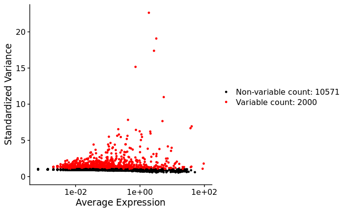

```r
plot1
```

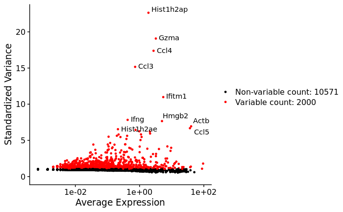

```r
plot2
```